# MPAs and climate change: analysis and plotting

Mark Ruddy

2017-04-29

## Task summary

The project aims to look at projected climate warming in Marine Protected Areas. It uses climate models ([CMIP5](http://cmip-pcmdi.llnl.gov/cmip5/)) run for two emission scenarios (Representative Concentration Pathways - [RCPs](https://www.skepticalscience.com/rcp.php?t=1)) - 4.5degC and 8.5degC - developed as part of Intergovernmental Panel on Climate Change’s (IPCC) Fifth Assessment Report ([AR5](http://www.ipcc-data.org/sim/gcm_monthly/AR5/)).

As part of the study, modelled temperature data need to be modified to exclude land-based temperature measures. Additionally, adequate output maps need to be created.

1. Code that removes the land surface temperatures from the CMIP5 surface temperature rasters.
2. Calculate mean temperature changes for specific geographic zones.
3. Plots of SST with land surface removed (white or black) and a pleasing SST key.

## Setup

```r
# Packages
library(dplyr) # Data wrangling and exploration
library(tidyr) # Data wrangling
library(ggplot2) # Plotting
library(viridis) # Perceptually sound palettes
library(gridExtra) # Grid arranged graphics
library(grid) # Grid arrangement
library(raster) # Dealing with rasters
library(rasterVis) # Dealing with rasters
library(sp) # Classes and methods for spatial data
library(ncdf4) # Required - viewing and working with climate data in netCDF format
library(rgdal) # For working with shapefiles
```

## Land surface temperature removal

### Approach

The approach I’ll take is to select cells from the CMIP5 grid that fall *wholly* within the boundary of the world land surface polygon. CMIP5 data is provided as a 360 * 180 (1 * 1 degree) grid. Raster-based analysis of temperatures - ie to quantify whole ocean or region warming - uses temperature data for each cell, so temperature values from single cells are what we’re interested in. By only discarding cells that fall entirely within the land surface we ensure that SSTs for MPAs found within grid cells that overlap coastlines will be retained for analysis.

During exploration of the process (see ‘mpa-raster-temperature-edit.Rmd’) it was found that around half CMIP raster cells intersecting with MPA points were being masked by the land polygon using `raster::mask`. Evidently these cells should be retained in the SST raster.

The cause of this problem was a combination of:

- Primarily the `raster::mask` algorithm, which selects cells ‘…if the polygon covers the center of a raster cell’. This will cause a number near-shore cells to be removed, and these cells may be ones containing MPAs.
- Secondarily - likely - error in the location of the MPAs or generalisation (simplification) of the small scale land surface polygons causing overlaps with near-shore MPAs. (This wasn’t investigated in depth because of time constraints).

So long as the study retains all cells that show sea temperatures and/or have MPA points in them we can be relaxed about how those cells are identified. A pragmatic approach is to:

1. Mask CMIP5 with land surface into ‘cmip.masked’ raster.
2. Use the MPA coordinates to identify from CMIP *only* the cells we want to retain in a ‘mpa.cells’ raster.
3. Merge ‘cmip.masked’ and ‘mpa.cells’ to give ‘cmip.sst’.

A summary of complete workflow in dummy code:

NOT RUN - DUMMY CODE

*Mask CMIP5 with land surface*

“cmip” is CMIP5 netCDF read in by raster

“land” is vector polygon land surface dataset

$> cmip.mask <- mask(x = cmip, mask = land, inverse = TRUE)

*Get MPA cells*

“mpas.xy” are the MPA longitude and latitude coordinate data

$> mpas <- SpatialPoints(mpas.xy) # Make MPAs into SpatialPoints class

$> mpa.cells <- mask(x = cmip, mask = mpas)

*Merge land masked CMIP5 and MPA cells*

$> cmip.sst <- merge(cmip.mask, mpa.cells)

### Read-in data

Requires land surface, and the CMIP5 mean RCP 8.5 climate model dataset will be used here.

Read in Marine Protected Areas

```r
mpas.in <- read.csv("../nn_extractedA2c.csv", header = TRUE)
mpas.in <- subset(x = mpas.in, subset = mpas.in$km<50) #subset the points less than 50 km from water
mpas.xy <- mpas.in[,2:3]
rm(mpas.in)
```

Read in CMIP5 RCP8.5 mean

```r
cmip <- "../trend_yearmean_ensemble_tos_RCP85.nc"
cmip <- raster(cmip) # Read in raster
map.extent <- c(-180, 180, -90, 90) # Reset for layer, orginal orientation was 0-360 longitude
extent(cmip) <- map.extent # Change extent

source("../revrotate.R") # Rotate raster layer to align with MPA points
cmip <- revrotate(cmip)
extent(cmip) <- map.extent

rm(map.extent, revrotate)
```

Obtain world land surface raster data

Read in [Natural Earth](http://www.naturalearthdata.com/) 1:110m world vector, then convert to simple raster.

```r
# Natural Earth 110m data. Comes as zip file
url <- "http://www.naturalearthdata.com/http//www.naturalearthdata.com/download/110m/physical/ne_110m_land.zip" # web location

localDir <- "../data"

if (!file.exists(localDir)) {
  dir.create(localDir)
}

dwnld <- paste(localDir, basename(url), sep = "/") # zip file destination

if (!file.exists(dwnld)) {
  download.file(url = url, destfile = dwnld, method = "auto") # download from web
  unzip(dwnld, exdir = localDir) # unzip
}

land <- readOGR(dsn = localDir) # Read in shapefile using `rgdal`. No need to specify shapefile name as there's only one in the directory we created above.
rm(url, localDir, dwnld) # clean up workspace
```

```r
## Mask CMIP5 with land surface ##
# "cmip" is CMIP5 netCDF read in by raster
# "land" is vector polygon land surface dataset
cmip.mask <- mask(x = cmip, mask = land, inverse = TRUE)

## Get MPA cells ##
# "mpas.xy" are the MPA longitude and latitude coordinate data
mpas <- SpatialPoints(mpas.xy) # Make MPAs into SpatialPoints class

mpa.cells <- mask(x = cmip, mask = mpas)

## Merge land masked CMIP5 and MPA cells ##
cmip.sst <- merge(cmip.mask, mpa.cells)

Summary(cmip.sst)
```

```
## class       : RasterLayer
## dimensions  : 180, 360, 64800  (nrow, ncol, ncell)
## resolution  : 1, 1  (x, y)
## extent      : -180, 180, -90, 90  (xmin, xmax, ymin, ymax)
## coord. ref. : +proj=longlat +datum=WGS84 +ellps=WGS84 +towgs84=0,0,0
## data source : in memory
## names       : layer
## values      : 0.001838005, 0.1606427  (min, max)
```

```r
rm(cmip.mask, mpa.cells)
```

Resulting CMIP raster has min = 0.0018 and max = 0.16 degC/year cell values.

Check for NA cells where MPAs are located

```r
mpa.check <- raster::extract(x = cmip.sst, y = SpatialPoints(mpas.xy)) # Use `raster::extract()` to disambiguate from `tidyr::extract()`
length(mpa.check[is.na(mpa.check)])
```

```
## [1] 0
```

```r
rm(mpa.check)
```

## Mean temperature of geographic zones

Define latitudinal zones. We’re just setting Northern hemisphere limits. Mirror image southern hemisphere limits will be derived within the function to calculate zonal means. `raster::extract` will be used, which selects cells by their centroid from `raster::extents`. This means we shouldn’t have duplicated cells contributing to different zones.

```r
# Find global means

# Find regional means.
# Latitudinal zone extents

global.lims <- c(0, 90)

## Tropical
trop.lims <- c(0, 23.5)

## Sub-tropical
subtrop.lims <- c(23.5, 40) # N and S subtropical zone limits.

## Temperate
temp.lims <- c(40, 66.5) # N and S temperate zone limits.

## Polar
polar.lims <- c(66.5, 90) # N and S polar zone limits.

## All extents
zone.lims <- list(global.lims, trop.lims, subtrop.lims, temp.lims, polar.lims)
```

Make data frame to hold zone names, limits and results.

```r
# Initialise data frame for outputs. A tibble.
zones <- c("global", "tropical", "sub-tropical", "temperate", "polar")

zone.means <- data_frame(
  zone = zones,
  limits = zone.lims,
  means = numeric(length = length(zones)), # Mean temperature
  count = numeric(length = length(zones)) # !is.na cell count for cross-checking data capture
)

rm(list = ls(pattern = ".*ext$|.*lims$"))
```

Calculate zonal mean temperature values.

```r
# Function to get raster means within extents
# raster = raster of values
# zones = df of zones, limits and empty values column for mean

source("../functions/multi.extent.means.R") # Applying raster::extract over zone dataframe

zone.means.sst <- multi.extent.means(cmip.sst, zone.means)

zone.means.sst # Sea temperatures
```

```
## # A tibble: 5 × 4
##           zone    limits      means count
##          <chr>    <list>      <dbl> <dbl>
## 1       global <dbl [2]> 0.04168230 44012
## 2     tropical <dbl [2]> 0.03225901 13289
## 3 sub-tropical <dbl [2]> 0.03119340  8433
## 4    temperate <dbl [2]> 0.03163841 13352
## 5        polar <dbl [2]> 0.08059313  8938
```

```r
# zone.means.all # Sea and land temperatures

rm(zones, zone.means, multi.extent.means, extent.mean)
```

!is.na cells in SST raster globally

```r
# !is.na cells in SST raster
length(getValues(cmip.sst))-summary(cmip.sst)[6]
```

```
## [1] 44012
```

Recombined !is.na cells

```r
sum(zone.means.sst$count[-1])
```

```
## [1] 44012
```

Cell totals from original SST raster and recombined zonal SST extracts match.

## Plotting

Aim is to produce plot of CMIP raster, MPAs and land surface for four areas:

1. Global
2. The Antarctic peninsula/southern South America
3. Australia, East Indies, Polynesia
4. Europe

The world plot contains some redundant areas near both poles - Antarctica and the Arctic are warped to a large size and the poles don’t contain any MPAs. We can trim these areas down to maximise the space avaiable for the rest of the globe. Something like crop at 80 degrees latitude seems appropriate. This is just for plotting, not for analysis.

Set some plot parameters for ease of use across all plots.

```r
# Size of axis text and guide bar text
axis_guide_text <- element_text(size = 12)
```

### Global plot

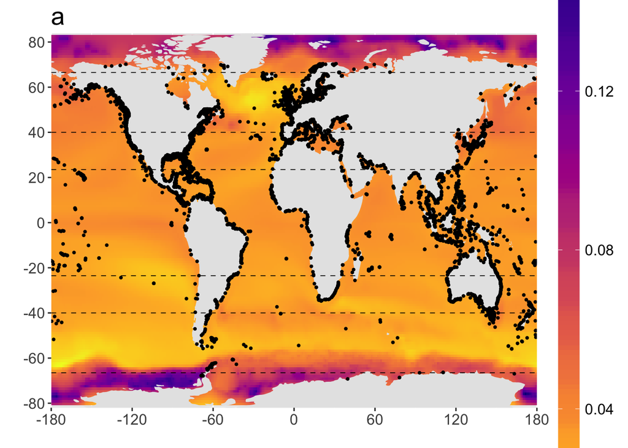

```r
##############
# Crop world land shapefile for better use of whole map space in plot using `raster::extract`
## Crop limits
crop.lim <- c(-180, 180, -82, 84)

## Crop land
crop.land <- crop(land, extent(crop.lim))
crop.land.gg <- fortify(crop.land) # Understandable by ggplot
##############

p.wld <- gplot(cmip) +
  # Note1: plotting raster uses `rasterVis::gplot` here not `ggplot`.
  # Note2: plot uses original cmip dataset without land-surface temperatures removed for aesthetic reasons - would otherwise show empty NA cells at some land margins.
  geom_raster(aes(fill = value)) +
  scale_fill_viridis(direction = -1, option = "plasma", breaks = seq(0, 0.16, 0.04)) +
  geom_polygon(data = crop.land.gg, aes(x = long, y = lat, group = group), fill = "grey90") +
  geom_point(data = mpas.xy, mapping = aes(x = Centroid_Longitude, y = Centroid_Latitude), size = 0.7, colour = "black") +
  guides(fill = guide_colorbar(title = expression(paste(degree, C,"/year")), barheight = 35, raster = TRUE)) +
  theme(legend.title = axis_guide_text, plot.title = element_text(size = 20, hjust = 0), axis.text = axis_guide_text, legend.text = axis_guide_text) +
  labs(title = "a") +
  xlab("") +
  ylab("") +
  scale_y_continuous(limits = crop.lim[3:4] , breaks = seq(-80, 80, 20), expand = c(0,0)) +
  scale_x_continuous(breaks = seq(-180, 180, 60), expand = c(0,0)) +
  geom_hline(yintercept = c(-66.5, -40, -23.5, 23.5, 40, 66.5), linetype = 2, size = 0.3)

p.wld
```

```r
ggsave(filename = "globe", plot =  p.wld, device = pdf, path = "../images", width = 13, height = 8, units = "in")

rm(lims, list = ls(patter = "^crop.*"))
```

### Antarctic plot.

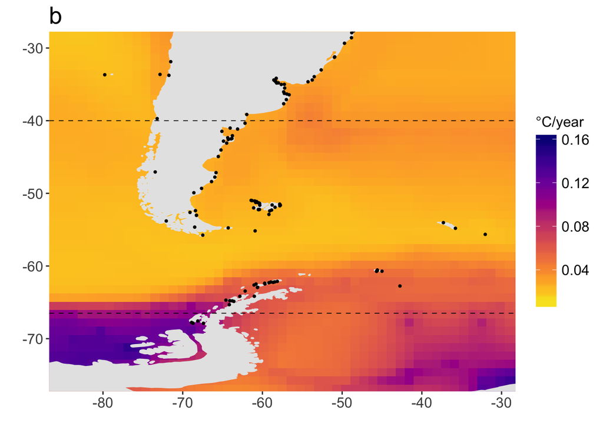

```r
##############
# Crop world land shapefile using `raster::extract`
## Limits
lims <- c(-90, -25, -80, -25) # Antarctic peninsula/southern South America

# Use `mapdata::world` land data here rather the more generalised Natural Earth .shp
world <- map_data(map = "world", interior = FALSE)

p.ant <- gplot(cmip) +
  # Note1: plotting raster uses `rasterVis::gplot` here not `ggplot`.
  # Note2: plot uses original cmip dataset without land-surface temperatures removed for aesthetic reasons - would otherwise show empty NA cells at some land margins.
  geom_raster(aes(fill = value)) +
  scale_fill_viridis(direction = -1, option = "plasma", breaks = seq(0, 0.16, 0.04)) +
  geom_map(data = world, map = world, aes(x = long, y = lat, map_id = region), colour = "grey90", fill = "grey90") +
  geom_point(data = mpas.xy, mapping = aes(x = Centroid_Longitude, y = Centroid_Latitude), size = 0.7, colour = "black") +
  guides(fill = guide_colorbar(title = expression(paste(degree, C,"/year")), barheight = 10, raster = TRUE)) +
    theme(legend.title = axis_guide_text, plot.title = element_text(size = 20, hjust = 0), axis.text = axis_guide_text, legend.text = axis_guide_text) +
  labs(title = "b") +
  xlab("") +
  ylab("") +
  # Had to hack `expand` within scale_... ? why not expanding data to plot edge with expand = c(0, 0)
  scale_y_continuous(limits = lims[3:4] , expand = c(-0.05, 0)) +
  scale_x_continuous(limits = lims[1:2], expand = c(-0.05,0)) +
  geom_hline(yintercept = c(-66.5, -40, -23.5, 23.5, 40, 66.5), linetype = 2, size = 0.3)
p.ant
```

```r
ggsave(filename = "ant", plot =  p.ant, device = pdf, path = "../images", width = 8, height = 8, units = "in")
rm(world, lims)
```

### Australia/East Indies plot.

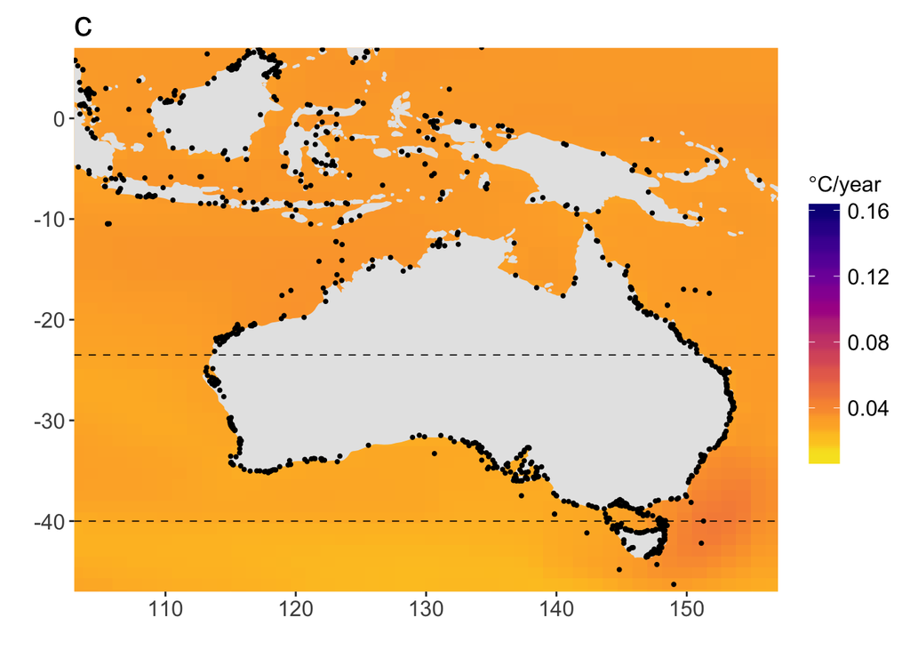

```r
##############
# Crop world land shapefile using `raster::extract`
## Limits
lims <- c(100, 160, -50, 10) # Australia, East Indies, Polynesia

# Use `mapdata::world` land data here rather the more generalised Natural Earth .shp
world <- map_data(map = "world", interior = FALSE)

p.aus <- gplot(cmip) +
  # Note1: plotting raster uses `rasterVis::gplot` here not `ggplot`.
  # Note2: plot uses original cmip dataset without land-surface temperatures removed for aesthetic reasons - would otherwise show empty NA cells at some land margins.
  geom_raster(aes(fill = value)) +
  scale_fill_viridis(direction = -1, option = "plasma", breaks = seq(0, 0.16, 0.04)) +
  geom_map(data = world, map = world, aes(x = long, y = lat, map_id = region), colour = "grey90", fill = "grey90") +
  geom_point(data = mpas.xy, mapping = aes(x = Centroid_Longitude, y = Centroid_Latitude), size = 0.7, colour = "black") +
  guides(fill = guide_colorbar(title = expression(paste(degree, C,"/year")), barheight = 10, raster = TRUE)) +
    theme(legend.title = axis_guide_text, plot.title = element_text(size = 20, hjust = 0), axis.text = axis_guide_text, legend.text = axis_guide_text) +
  labs(title = "c") +
  xlab("") +
  ylab("") +
  # Had to hack `expand` within scale_... ? why not expanding data to plot edge with expand = c(0, 0)
  scale_y_continuous(limits = lims[3:4] , expand = c(-0.05, 0)) +
  scale_x_continuous(limits = lims[1:2], expand = c(-0.05,0)) +
  geom_hline(yintercept = c(-66.5, -40, -23.5, 23.5, 40, 66.5), linetype = 2, size = 0.3)
p.aus
```

```r
ggsave(filename = "aus", plot =  p.aus, device = pdf, path = "../images", width = 8, height = 8, units = "in")
rm(world, lims)
```

### Europe plot.

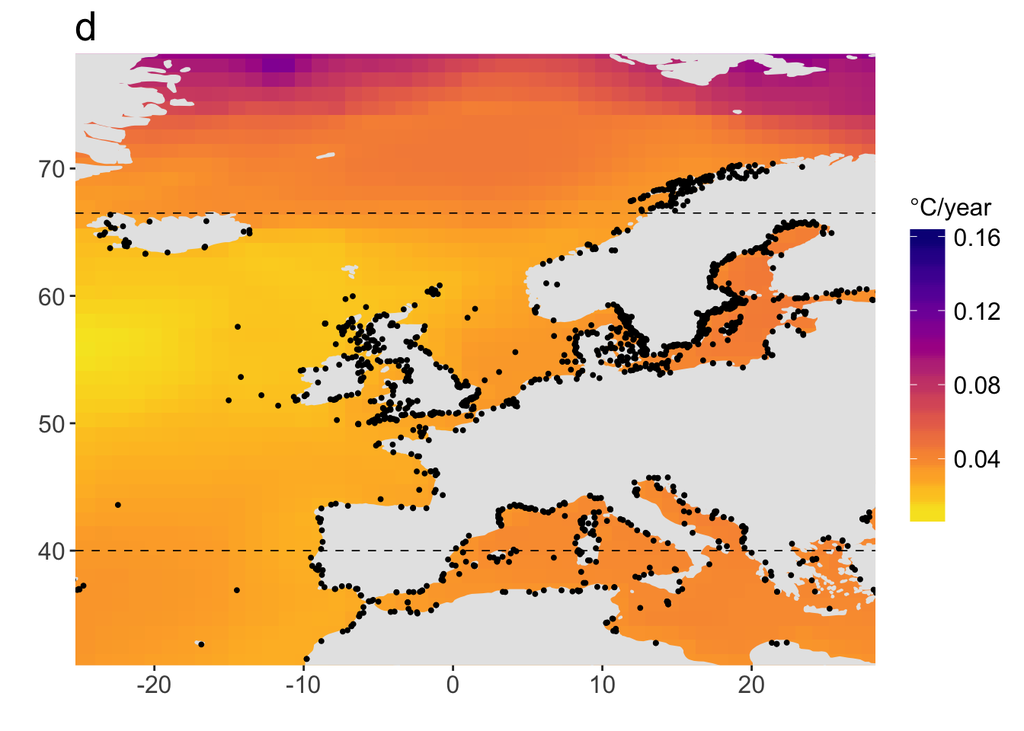

```r
##############
# Crop world land shapefile using `raster::extract`
## Limits
lims <- c(-27, 30, 30, 80) # Europe

# Use `mapdata::world` land data here rather the more generalised Natural Earth .shp
world <- map_data(map = "world", interior = FALSE)

p.eur <- gplot(cmip) +
  # Note1: plotting raster uses `rasterVis::gplot` here not `ggplot`.
  # Note2: plot uses original cmip dataset without land-surface temperatures removed for aesthetic reasons - would otherwise show empty NA cells at some land margins.
  geom_raster(aes(fill = value)) +
  scale_fill_viridis(direction = -1, option = "plasma", breaks = seq(0, 0.16, 0.04)) +
  geom_map(data = world, map = world, aes(x = long, y = lat, map_id = region), colour = "grey90", fill = "grey90") +
  geom_point(data = mpas.xy, mapping = aes(x = Centroid_Longitude, y = Centroid_Latitude), size = 0.7, colour = "black") +
  guides(fill = guide_colorbar(title = expression(paste(degree, C,"/year")), barheight = 10, raster = TRUE)) +
    theme(legend.title = axis_guide_text, plot.title = element_text(size = 20, hjust = 0), axis.text = axis_guide_text, legend.text = axis_guide_text) +
  labs(title = "d") +
  xlab("") +
  ylab("") +
  # Had to hack `expand` within scale_... ? why not expanding data to plot edge with expand = c(0, 0)
  scale_y_continuous(limits = lims[3:4] , expand = c(-0.02, 0)) +
  scale_x_continuous(limits = lims[1:2], expand = c(-0.03,0)) +
  geom_hline(yintercept = c(-66.5, -40, -23.5, 23.5, 40, 66.5), linetype = 2, size = 0.3)
p.eur
```

```r
ggsave(filename = "eur", plot =  p.eur, device = pdf, path = "../images", width = 8, height = 8, units = "in")
rm(world, lims)
```

### Grid plot

`gridExtra::grid.arrange` gives us the arrangement we want; with 1:4 plots on the left and a single guide on the right.

Plot with ggplot grobs (graphical objects)

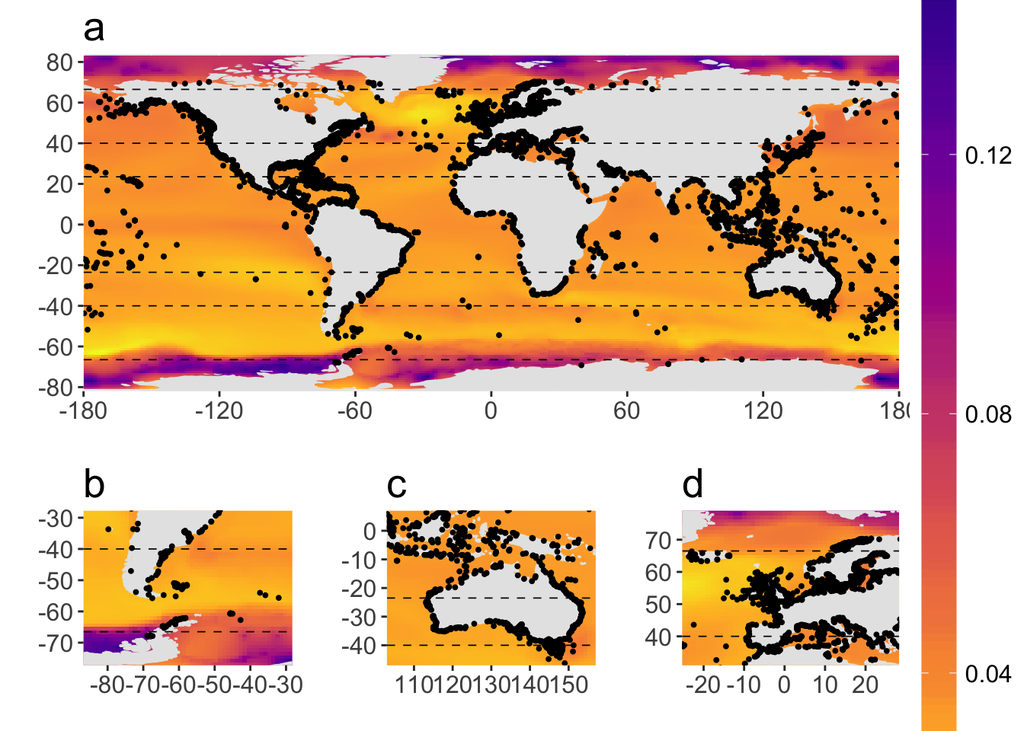

```r
# List of plots
plist <- list(p.wld, p.ant, p.aus, p.eur)

# Get legend as grob
g <- ggplotGrob(p.wld + theme(legend.position = "right"))$grobs
legend <- g[[which(sapply(g, function(x) x$name) == "guide-box")]]

# Remove legends from plots
plist <- lapply(plist, function(x) x + theme(legend.position="none"))

# Arrange plots in grid
mp <- grid.arrange(
  arrangeGrob(plist[[1]],
              do.call(arrangeGrob, c(plist[2:4], ncol=3, list(widths=c(1,1,1)))),
          nrow=2, heights=c(5,3)), legend, nrow=1, widths=c(8,1))
```

```r
ggsave(filename = "multi-plot", plot = mp, path = "../images/", device = "pdf", units = "in", width = 12, height = 10)

rm(plist, g, mp, legend)
```